# Cyclistic Bike-Share Analysis: Comparing Casual Riders and Annual Members Using R

## Missing Values (NA) Inspection & Resolution

**Rationale:**  
Carefully reviewed missing values (NAs) to assess potential impacts.

- **2019 Dataset:**
  - Most NAs in demographic columns (`gender`, `birth_year`).
  - Retained these records as missing demographics likely due to incomplete optional user profiles, not critical to the analysis.
- **2020 Dataset:**
  - Identified a single problematic record (NAs in key fields plus negative duration), clearly an erroneous entry. Removed this record confidently.

```r
# Function to summarize missing values clearly by dataset
na_summary <- function(df, year) {
  df %>%
    summarise(across(everything(), ~sum(is.na(.)))) %>%
    pivot_longer(everything(), names_to = "column", values_to = "na_count") %>%
    filter(na_count > 0) %>%
    arrange(desc(na_count)) %>%
    mutate(year = year)
}

# Review NA summaries
print("NA Summary (2019):")
```

```
## [1] "NA Summary (2019):"
```

```r
print(na_summary(df_2019, "2019"))
```

```
## # A tibble: 2 × 3
##   column    na_count year
##   <chr>        <int> <chr>
## 1 gender       19711 2019
## 2 birthyear    18023 2019
```

```r
print("NA Summary (2020):")
```

```
## [1] "NA Summary (2020):"
```

```r
print(na_summary(df_2020, "2020"))
```

```
## # A tibble: 4 × 3
##   column           na_count year
##   <chr>               <int> <chr>
## 1 end_station_name        1 2020
## 2 end_station_id          1 2020
## 3 end_lat                 1 2020
## 4 end_lng                 1 2020
```

```r
# Inspect problematic row in 2020
na_rows_2020 <- df_2020 %>%
  filter(is.na(end_station_id) | is.na(end_lat) | is.na(end_lng))

print("Problematic NA row (2020 dataset):")
```

```
## [1] "Problematic NA row (2020 dataset):"
```

```r
print(na_rows_2020)
```

```
## # A tibble: 1 × 14
##   ride_id          rideable_type started_at          ended_at
##   <chr>            <chr>         <dttm>              <dttm>
## 1 157EAA4C4A3C8D36 docked_bike   2020-03-16 11:23:36 2020-03-16 11:23:24
## # ℹ 10 more variables: start_station_name <chr>, start_station_id <dbl>,
## #   end_station_name <chr>, end_station_id <dbl>, start_lat <dbl>,
## #   start_lng <dbl>, end_lat <dbl>, end_lng <dbl>, member_casual <chr>,
## #   tripduration_calculated <int>
```

```r
# Identify and remove clearly problematic rows in the 2020 dataset
df_2020 <- df_2020 %>%
  filter(!(is.na(end_station_id) | is.na(end_lat) | is.na(end_lng)))
```

## Final Dataset Integration & Checks

*Integrated the datasets, split timestamps into separate date/time columns explicitly, determined start day of the week, and verified integrity:*

```r
# Combine cleaned datasets and create additional analytical columns
df_combined <- bind_rows(df_2019, df_2020) %>%
  rename(tripduration = tripduration_calculated) %>%
  mutate(
    start_date = as.Date(started_at),
    end_date = as.Date(ended_at),
    start_time = as_hms(started_at),
    end_time = as_hms(ended_at),
    start_day = weekdays(start_date)
  ) %>%
  select(ride_id, member_casual, started_at, ended_at, start_day, start_date, start_time, end_date, end_time, tripduration, everything())

# Ensure days of the week are ordered properly for clarity
df_combined$start_day <- factor(
  df_combined$start_day,
  levels = c("Monday", "Tuesday", "Wednesday", "Thursday", "Friday", "Saturday", "Sunday"), ordered = TRUE
  )

# Final dataset integrity check
stopifnot(nrow(df_combined) == nrow(df_2019) + nrow(df_2020))

# Quick inspection of final dataset structure
glimpse(df_combined)
```

```
## Rows: 791,955
## Columns: 22
## $ ride_id            <chr> "21742443", "21742444", "21742445", "21742446", "21…
## $ member_casual      <chr> "member", "member", "member", "member", "member", "…
## $ started_at         <dttm> 2019-01-01 00:04:37, 2019-01-01 00:08:13, 2019-01-…
## $ ended_at           <dttm> 2019-01-01 00:11:07, 2019-01-01 00:15:34, 2019-01-…
## $ start_day          <ord> Tuesday, Tuesday, Tuesday, Tuesday, Tuesday, Tuesda…
## $ start_date         <date> 2019-01-01, 2019-01-01, 2019-01-01, 2019-01-01, 20…
## $ start_time         <time> 00:04:37, 00:08:13, 00:13:23, 00:13:45, 00:14:52, …
## $ end_date           <date> 2019-01-01, 2019-01-01, 2019-01-01, 2019-01-01, 20…
## $ end_time           <time> 00:11:07, 00:15:34, 00:27:12, 00:43:28, 00:20:56, …
## $ tripduration       <int> 390, 441, 829, 1783, 364, 216, 177, 100, 1727, 336,…
## $ bikeid             <dbl> 2167, 4386, 1524, 252, 1170, 2437, 2708, 2796, 6205…
## $ start_station_id   <dbl> 199, 44, 15, 123, 173, 98, 98, 211, 150, 268, 299, …
## $ start_station_name <chr> "Wabash Ave & Grand Ave", "State St & Randolph St",…
## $ end_station_id     <dbl> 84, 624, 644, 176, 35, 49, 49, 142, 148, 141, 295, …
## $ end_station_name   <chr> "Milwaukee Ave & Grand Ave", "Dearborn St & Van Bur…
## $ gender             <chr> "Male", "Female", "Female", "Male", "Male", "Female…
## $ birthyear          <dbl> 1989, 1990, 1994, 1993, 1994, 1983, 1984, 1990, 199…
## $ rideable_type      <chr> NA, NA, NA, NA, NA, NA, NA, NA, NA, NA, NA, NA, NA,…
## $ start_lat          <dbl> NA, NA, NA, NA, NA, NA, NA, NA, NA, NA, NA, NA, NA,…
## $ start_lng          <dbl> NA, NA, NA, NA, NA, NA, NA, NA, NA, NA, NA, NA, NA,…
## $ end_lat            <dbl> NA, NA, NA, NA, NA, NA, NA, NA, NA, NA, NA, NA, NA,…
## $ end_lng            <dbl> NA, NA, NA, NA, NA, NA, NA, NA, NA, NA, NA, NA, NA,…
```

## Verification of Data Cleanliness

- No unresolved critical missing values.
- Data types clearly standardized.
- Columns clearly aligned and verified.
- Row count validated.

**Outcome:**  
The final combined data set (`df_combined`) is rigorously cleaned, standardized, and explicitly documented, ready for reliable analysis of casual versus annual rider behaviors.

# Analyze Phase

Now that our data is cleaned, standardized, and combined (`df_combined`), we proceed with analysis to uncover trends, relationships, and insights distinguishing between **casual riders** and **annual members**.

## Descriptive Statistics on Ride Metrics

### Mean Ride Length by User Type

Calculate the average ride length explicitly for casual riders and members.

```r
# Average Ride Duration by Rider Type
stats_rideLength_mean <- df_combined %>%
  group_by(member_casual) %>%
  summarize(mean_duration_minutes = mean(tripduration, na.rm = TRUE)/60)

print(stats_rideLength_mean)
```

```
## # A tibble: 2 × 2
##   member_casual mean_duration_minutes
##   <chr>                         <dbl>
## 1 casual                         84.8
## 2 member                         13.3
```

### Maximum Ride Length by User Type

Identify the maximum recorded ride duration clearly for each rider type.

```r
# Maximum Ride Duration by Rider Type
stats_rideLength_max <- df_combined %>%
  group_by(member_casual) %>%
  summarize(max_duration_minutes = max(tripduration, na.rm = TRUE)/60)

print(stats_rideLength_max)
```

```
## # A tibble: 2 × 2
##   member_casual max_duration_minutes
##   <chr>                        <dbl>
## 1 casual                     177200.
## 2 member                     101607.
```

### Mode of Day of the Week

Determine the most frequently occurring day of the week explicitly for rides overall.

```r
# Most Frequent Ride Day
stats_weekDay_mode <- df_combined %>%
  count(start_day) %>%
  arrange(desc(n)) %>%
  slice(1)

print(stats_weekDay_mode)
```

```
## # A tibble: 1 × 2
##   start_day      n
##   <ord>      <int>
## 1 Tuesday   135966
```

### Average Ride Length by User Type Alone

```r
# Average ride duration in minutes for each user type (casual vs. member)
user_avgLength <- df_combined %>%
  group_by(member_casual) %>%
  summarize(average_duration_minutes = mean(tripduration, na.rm = TRUE)/60)

print(user_avgLength)
```

```
## # A tibble: 2 × 2
##   member_casual average_duration_minutes
##   <chr>                            <dbl>
## 1 casual                            84.8
## 2 member                            13.3
```

## Trends and Relationships by Day of Week

Analyze ride behavior explicitly across different weekdays to reveal clear patterns.

### Average Ride Length by both Day of Week and User Type

Evaluate explicitly how average ride duration vary by weekday and rider type.

```r
# Evaluate average ride duration (in minutes) explicitly segmented by rider type across each weekday
dayUser_avgLength <- df_combined %>%
  group_by(member_casual, start_day) %>%
  summarize(average_duration_minutes = mean(tripduration, na.rm = TRUE)/60) %>%
  pivot_wider(names_from = start_day, values_from = average_duration_minutes)
print(dayUser_avgLength)
```

```
## # A tibble: 2 × 8
## # Groups:   member_casual [2]
##   member_casual Monday Tuesday Wednesday Thursday Friday Saturday Sunday
##   <chr>          <dbl>   <dbl>     <dbl>    <dbl>  <dbl>    <dbl>  <dbl>
## 1 casual          65.7    69.6      68.2    129.    95.2     82.5   84.4
## 2 member          13.7    12.8      11.9     11.8   13.3     16.2   16.2
```

### Total Number of Rides by both Day of Week and User Type

Identify how total rides clearly vary across weekdays, explicitly distinguishing casual riders from annual members.

```r
# Calculate total ride counts explicitly segmented by rider type across each weekday
dayUser_totalRides <- df_combined %>%
  group_by(member_casual, start_day) %>%
  summarize(total_rides = n()) %>%
  pivot_wider(names_from = start_day, values_from = total_rides)
print(dayUser_totalRides)
```

```
## # A tibble: 2 × 8
## # Groups:   member_casual [2]
##   member_casual Monday Tuesday Wednesday Thursday Friday Saturday Sunday
##   <chr>          <int>   <int>     <int>    <int>  <int>    <int>  <int>
## 1 casual          6746    7992      8422     7815   8542    13473  18652
## 2 member        110430  127974    121903   125228 115168    59413  60197
```

## Trends by Q1 Month

To explore overall impacts during Q1, analyze the ride behaviors explicitly by month.

### Add Month Column

Create a clear month-based categorization.

```r
# Monthly Trends
df_combined <- df_combined %>%
  mutate(month = month(started_at, label = TRUE, abbr = FALSE))

head(df_combined %>% select(started_at, month))
```

```
## # A tibble: 6 × 2
##   started_at          month
##   <dttm>              <ord>
## 1 2019-01-01 00:04:37 January
## 2 2019-01-01 00:08:13 January
## 3 2019-01-01 00:13:23 January
## 4 2019-01-01 00:13:45 January
## 5 2019-01-01 00:14:52 January
## 6 2019-01-01 00:15:33 January
```

### Average Ride Length by Q1 Month and User Type

Evaluate how monthly ride duration explicitly varies by rider type.

```r
# Calculate the average ride duration (minutes) explicitly segmented by month and rider type
monthUser_avgLength <- df_combined %>%
  group_by(member_casual, month) %>%
  summarize(avg_duration_minutes = mean(tripduration, na.rm = TRUE)/60) %>%
  pivot_wider(names_from = month, values_from = avg_duration_minutes)
print(monthUser_avgLength)
```

```
## # A tibble: 2 × 4
## # Groups:   member_casual [2]
##   member_casual January February March
##   <chr>           <dbl>    <dbl> <dbl>
## 1 casual          119.     131.   58.9
## 2 member           13.0     13.1  13.6
```

### Total Rides by Q1 Month and User Type

Summarize how total ride counts clearly vary by month, differentiating explicitly between rider categories.

```r
# Calculate total number of rides explicitly segmented by month and rider type
monthUser_totalRides <- df_combined %>%
  group_by(member_casual, month) %>%
  summarize(total_rides = n()) %>%
  pivot_wider(names_from = month, values_from = total_rides)
print(monthUser_totalRides)
```

```
## # A tibble: 2 × 4
## # Groups:   member_casual [2]
##   member_casual January February  March
##   <chr>           <int>    <int>  <int>
## 1 casual          12387    15508  43747
## 2 member         234769   220263 265281
```

## Summary of Analytical Observations

### Business Implications:

- Target **weekend** and **early-spring promotions** explicitly toward casual riders to convert leisure-oriented riders into annual subscribers.
- Highlight **annual membership benefits** to casual riders commuting during weekdays, emphasizing consistent convenience and potential cost savings.
- Utilize identified seasonal and daily usage patterns to strategically schedule targeted marketing campaigns, maximizing conversion opportunities.

# Share Phase

The visualizations presented here clearly illustrate the explicit differences in usage patterns between **casual riders** and **annual members**. The insights are strategically designed to support Cyclistic’s executive team in decision-making around targeted marketing strategies.

## Average Ride Duration by Rider Type

Illustrate the difference in average ride lengths between casual riders and annual members.

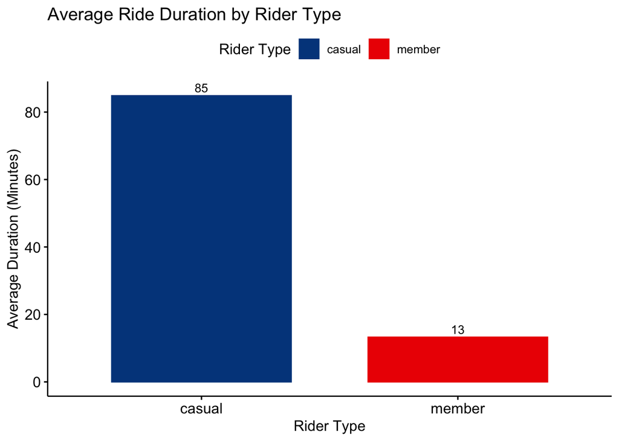

```r
# Summarize the average ride duration in minutes by rider type
df_plot <- df_combined %>%
  group_by(member_casual) %>%
  summarize(avg_duration_minutes = mean(tripduration) / 60)

# Bar plot illustrating the explicit difference in average ride length
ggbarplot(
  df_plot,
  x = "member_casual",
  y = "avg_duration_minutes",
  fill = "member_casual",
  color = "member_casual",
  palette = "lancet",
  label = round(df_plot$avg_duration_minutes, 0),
  lab.pos = "out",
  lab.size = 3.5,
  xlab = "Rider Type",
  ylab = "Average Duration (Minutes)",
  legend.title = "Rider Type",
  title = "Average Ride Duration by Rider Type"
  )
```

## Average Ride Duration by Day of Week and Rider Type

Highlights weekday vs weekend differences between casual riders and members.

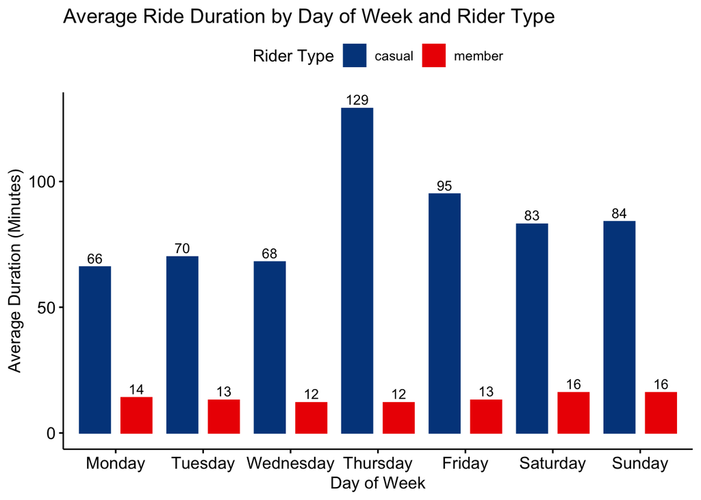

```r
# Calculate average ride duration by day of the week and rider type
df_plot <- df_combined %>%
  group_by(member_casual, start_day) %>%
  summarize(avg_duration_minutes = round(mean(tripduration, na.rm = TRUE) / 60, 0), .groups = 'drop')

# Bar plot explicitly comparing weekday vs weekend ride durations
ggbarplot(
  df_plot,
  x = "start_day",
  y = "avg_duration_minutes",
  fill = "member_casual",
  color = "member_casual",
  palette = "lancet",
  position = position_dodge(),
  label = TRUE,
  lab.size = 3.5,
  xlab = "Day of Week",
  ylab = "Average Duration (Minutes)",
  legend.title = "Rider Type",
  title = "Average Ride Duration by Day of Week and Rider Type"
  )
```

## Total Number of Rides by Day of Week and Rider Type

Illustrates rider preference by weekdays and weekends.

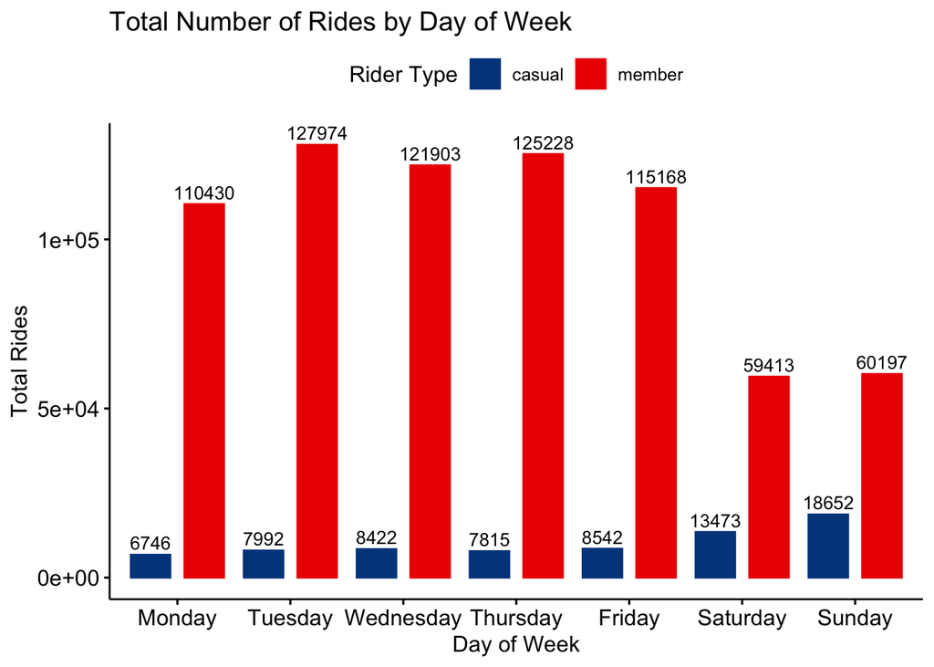

```r
# Summarize total number of rides explicitly grouped by day of week and rider type
df_plot <- df_combined %>%
  group_by(member_casual, start_day) %>%
  summarize(total_rides = n())
# Bar plot clearly highlighting rider preference across the weekdays and weekends
ggbarplot(
  df_plot,
  x = "start_day",
  y = "total_rides",
  fill = "member_casual",
  color = "member_casual",
  palette = "lancet",
  position = position_dodge(),
  label = TRUE,
  lab.size = 3.5,
  xlab = "Day of Week",
  ylab = "Total Rides",
  legend.title = "Rider Type",
  title = "Total Number of Rides by Day of Week"
  )
```

## Monthly Trends in Ride Counts by Rider Type

Illustrates seasonal differences in ridership.

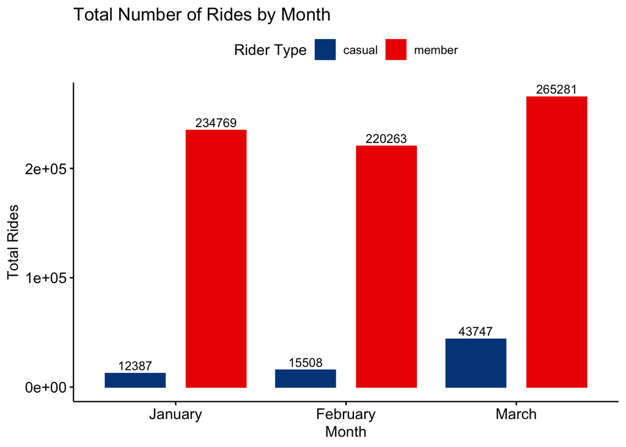

```r
# Summarize total ride counts explicitly grouped by month and rider type
df_plot <- df_combined %>%
  group_by(member_casual, month) %>%
  summarize(total_rides = n(), .groups = 'drop')

# Ensure months are clearly ordered for accurate seasonal analysis
df_plot$month <- factor(df_plot$month, levels = month.name, ordered = TRUE)

# Bar plot illustrating seasonal differences in rider counts explicitly
ggbarplot(
  df_plot,
  x = "month",
  y = "total_rides",
  fill = "member_casual",
  color = "member_casual",
  palette = "lancet",
  position = position_dodge(),
  label = TRUE,
  lab.size = 3.5,
  xlab = "Month",
  ylab = "Total Rides",
  legend.title = "Rider Type",
  title = "Total Number of Rides by Month"
  )
```

## Percentage Share of Rides by Rider Type and Month

Ilustrate how the proportion of casual riders relative to annual members shifts throughout Q1, emphasizing seasonal trends and strategic marketing opportunities.

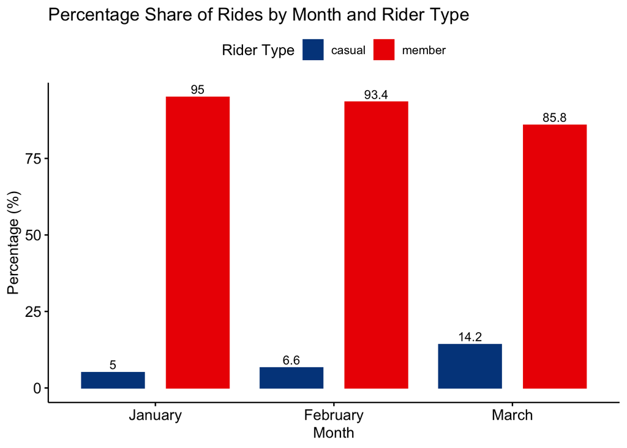

```r
# Calculate the percentage share of total rides for each rider type explicitly by month
df_plot <- df_combined %>%
  group_by(month, member_casual) %>%
  summarize(total_rides = n(), .groups = 'drop') %>%
  group_by(month) %>%
  mutate(percent_share = total_rides / sum(total_rides) * 100)

# Convert month to clearly ordered factor for intuitive plotting
df_plot$month <- factor(df_plot$month, levels = month.name, ordered = TRUE)

# Bar plot clearly illustrating monthly shifts in casual vs annual rider proportions
ggbarplot(
  df_plot,
  x = "month",
  y = "percent_share",
  fill = "member_casual",
  color = "member_casual",
  palette = "lancet",
  position = position_dodge(),
  label = round(df_plot$percent_share, 1),
  lab.size = 3.5,
  lab.pos = "out",
  xlab = "Month",
  ylab = "Percentage (%)",
  legend.title = "Rider Type",
  title = "Percentage Share of Rides by Month and Rider Type"
  )
```

# Act Phase

Based on the comprehensive analysis and visualizations provided, we now clearly outline actionable recommendations to guide Cyclistic’s strategic marketing decisions.

## Final Conclusion

The analysis explicitly highlights substantial differences between **casual riders** and **annual members**:

These clear distinctions present Cyclistic with targeted opportunities for marketing campaigns explicitly designed to convert casual riders into annual members.

## Top Three Recommendations

### Launch Weekend and Seasonal Promotional Campaigns

**Recommendation:**  
Create targeted weekend and seasonal membership promotions, explicitly incentivizing casual riders with special discounts or time-limited offers during peak leisure periods.

### Target Commuter Conversion with Weekday-Focused Campaigns

**Insight:**  
Annual members exhibit regular, short weekday rides indicative of commuting behavior, whereas casual riders might commute occasionally without annual commitment.

**Recommendation:**  
Develop explicit commuter-oriented messaging highlighting cost-effectiveness, convenience, reliability, and long-term savings associated with annual memberships to convert casual riders into regular commuting members.

### Personalize Engagement and Loyalty Incentives

**Insight:**  
Casual riders’ longer rides indicate significant opportunities for personalized engagement and incentive-based loyalty programs.

**Recommendation:**  
Implement explicit personalized incentive programs, such as loyalty points, discounts on long-duration rides, or milestone-based rewards to increase rider engagement and encourage casual riders to convert to annual membership.

## Application of Insights by the Business

The Cyclistic team can explicitly leverage these insights as follows:

- **Marketing Analytics Team:**
  - Utilize these clear rider distinctions to refine segmentation and create targeted, behavior-driven campaigns.
- **Marketing Director (Lily Moreno):**
  - Explicitly allocate marketing budgets toward high-impact seasonal and commuter-focused campaigns, guided directly by insights.
- **Executive Team:**
  - Base strategic marketing decisions explicitly on data-supported evidence to confidently approve campaigns designed for maximum conversion effectiveness and revenue growth.

## Recommended Next Steps

To effectively implement these recommendations, stakeholders should:

- **Pilot Testing:**  
  Launch initial campaigns explicitly targeted at select neighborhoods to evaluate effectiveness before broader implementation.
- **Performance Tracking:**  
  Clearly define and measure performance metrics, including conversion rates, membership growth, and ROI, over specific evaluation periods (3-6 months).
- **Continuous Optimization:**  
  Regularly review and update campaigns based on newly gathered data, clearly ensuring sustained effectiveness and relevance.

## Additional Data for Further Analysis

Collecting the following explicit additional data could further enhance strategic clarity:

- **Rider Demographic Data:**  
  Age, income, residential area, and preferences for improved targeting.
- **Qualitative Feedback:**  
  Rider surveys explicitly capturing motivations and barriers to annual membership adoption.
- **Competitive Market Analysis:**  
  Data on competitor promotions and market trends for ongoing strategic advantage.